# 2017-10-02-python

## NumPy에 대해 알아보자. ④

## sort

```python
import numpy as np

a = np.array([[4, 3, 5], [1, 2, 1]])
a
```

```
array([[4, 3, 5],
       [1, 2, 1]])
```

```python
a[:,0]
```

```
array([4, 1])
```

```python
# 세로 정렬
b = np.sort(a, axis=0)
b
```

```
array([[1, 2, 1],
       [4, 3, 5]])
```

```python
# 가로 정렬
b = np.sort(a, axis=1)
b
```

```
array([[3, 4, 5],
       [1, 1, 2]])
```

### `np.argsort( )`

> 순서를 저장한다.

```python
a = np.array([4, 3, 1, 2])
j = np.argsort(a)
j
```

```
array([2, 3, 1, 0])
```

```python
a[j]
```

```
array([1, 2, 3, 4])
```

### array를 정렬한다. → (1, 2, 3, 4)

> **1의 자리는 3번째(2), 2의 자리는 4번째(3), 3의 자리는 2번째(1), 4의 자리는 1번째(0)**

> **위 처럼 값을 sorting한 후 sorting 전 array를 보면서 순서를 출력한다.**

### Array용 수학 함수

> **universal function**
> - 빠른 element-wise (vectorized) 연산

> **모든 NumPy/Scipy 수학 함수는 자동으로 vectorized 연산 수행**

```python
x = range(10)
x
```

```
range(0, 10)
```

```python
import math

math.exp(x)
```

```
---------------------------------------------------------------------------
TypeError                                 Traceback (most recent call last)
<ipython-input-8-f80941f67f52> in <module>()
      1 import math
      2
----> 3 math.exp(x)

TypeError: must be real number, not range
```

**`math` 모듈을 사용할 경우, vectorized 연산을 수행하지 못한다.**

**아래처럼 list comprehension을 사용해서 그 값을 직접 구해야한다.**

```python
math.exp(x[0])
```

```
1.0
```

```python
[math.exp(x_i) for x_i in x]
```

```
[1.0,
 2.718281828459045,
 7.38905609893065,
 20.085536923187668,
 54.598150033144236,
 148.4131591025766,
 403.4287934927351,
 1096.6331584284585,
 2980.9579870417283,
 8103.083927575384]
```

#### 하지만, numpy를 사용할 경우, 아래처럼 vectorized 연산을 수행하면 된다.

```python
np.exp(x)
```

```
array([  1.00000000e+00,   2.71828183e+00,   7.38905610e+00,
         2.00855369e+01,   5.45981500e+01,   1.48413159e+02,
         4.03428793e+02,   1.09663316e+03,   2.98095799e+03,
         8.10308393e+03])
```

### `numpy.random` 서브패키지

- `seed`: pseudo random 상태 설정
- `shuffle`: 조합(combination)
- `choice`: 순열(permutation) 및 조합(combination)
- `rand`: uniform
- `random_integers`: uniform integer
- `randn`: Gaussina normal

### seed

- 컴퓨터의 랜덤 생성은 사실 랜덤이 아니다.
- 랜덤처럼 보이지만 정해진 알고리즘에 의해 생성되는 규칙적인 순열
- 시작점이 정해지면 랜덤 함수를 사용해도 정해진 숫자가 나온다.

```python
np.random.seed(0)
```

- `numpy.random.shuffle(x)`
  > - Parameters:
  >   - x : array_like
  >     - The array or list to be shuffled.
  > - 섞는 것(카드 섞는 것처럼) / **비복원 추출이다!**

```python
x = np.arange(10)
np.random.shuffle(x)
x
```

```
array([2, 8, 4, 9, 1, 6, 7, 3, 0, 5])
```

#### 위의 결과를 보면, x의 순서가 섞였다.

- `numpy.random.choice(a, size=None, replace=True, p=None)`
  - Parameters:
    - a : 1-D array-like or int
      - 데이터를 넣어주면 된다. 배열이면 원래의 데이터, 정수이면 range(a) 명령으로 데이터 생성
    - size : int or tuple of ints, optional
      - 정수. 샘플 숫자 shape으로 넣으면 매트릭스를 생성
    - replace : boolean, optional → 복원 / 비복원 선택
      - 중복의 허용 여부. 불리언. True이면 한번 선택한 데이터를 다시 선택 가능
    - p : 1-D array-like, optional
      - 배열. 각 데이터가 선택될 수 있는 확률
  - Returns:
    - samples : 1-D ndarray, shape (size,)
      - The generated random samples

```python
# same as shuffle, 비복원으로 뽑으므로 shuffle과 같다.
## 5개(0,1,2,3,4) 중에 5개, 비복원
np.random.choice(5, 5, replace=False)
```

```
array([1, 0, 2, 3, 4])
```

```python
## 5개(0,1,2,3,4) 중에 3개, 비복원
np.random.choice(5, 3, replace=False)
```

```
array([3, 1, 2])
```

```python
## 5개(0,1,2,3,4) 중에 10개, 복원
np.random.choice(5, 10)
```

```
array([0, 1, 1, 0, 1, 4, 3, 0, 3, 0])
```

```python
## 5개(0,1,2,3,4) 중에 10번 추출, 복원
# 확률의 가중치를 줌.
np.random.choice(5, 10, p=[0.1, 0, 0.3, 0.6, 0])
```

```
array([3, 3, 3, 3, 2, 3, 2, 3, 3, 3])
```

```
[ 0.26455561  0.77423369  0.45615033  0.56843395  0.0187898   0.6176355
  0.61209572  0.616934    0.94374808  0.6818203 ]
```

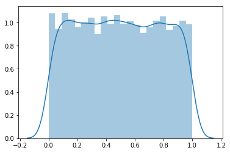

```python
import seaborn as sns
%matplotlib inline

# uniform 분포에서 (0, 1)범위에서 10,000개를 뽑아라.
x = np.random.rand(10000)

print(x[:10])
sns.distplot(x)
```

```python
np.random.rand(3,2)
```

```
array([[ 0.87423081,  0.47428492],
       [ 0.66369491,  0.88164841],
       [ 0.30465899,  0.89576302]])
```

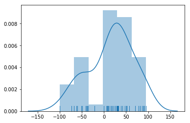

```python
# uniform 분포 범위 지정 (-100, 100)에서 50개를 찍어라.
x = np.random.random_integers(-100, 100, 50)

## rug = True → 실제 점 찍힌 것을 표현
sns.distplot(x, rug=True)
```

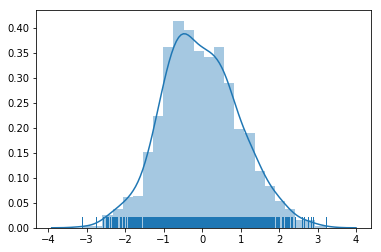

```python
# 가우시안 정규 분포에서 1,000개 랜덤 추출
x = np.random.randn(1000)
sns.distplot(x, rug=True)
```

```python
np.random.randn(3,4)
```

```
array([[-0.24084301, -0.6676534 ,  0.06900028,  0.45158204],
       [-0.23342743, -0.33696328, -0.49507512, -0.49871364],
       [-0.18672772,  0.24499567, -0.77532038, -0.23060432]])
```

### random number count

- discrete values → 이 값만 쓸 수 있다.
  > - `unique()`
  > - `bincount()`
- continuous values → 구간으로 나누어 히스토그램으로 표현
  > - `histogram()`

```python
np.unique([11, 11, 2, 2, 34, 34])
```

```
array([ 2, 11, 34])
```

```python
a = np.array([[1, 1], [2, 3]])
a, np.unique(a)
```

```
(array([[1, 1],
        [2, 3]]), array([1, 2, 3]))
```

```python
a = np.array(['a', 'b', 'b', 'c', 'a'])

# index가 각각 몇 번 나왔는지 표현
index, count = np.unique(a, return_counts=True)
```

```python
index, count
```

```
(array(['a', 'b', 'c'],
       dtype='<U1'), array([2, 2, 1]))
```

### count → 한 번도 나오지 않는 애들은 세지 않는다.

### bincount → 한 번도 안 나온 애들은 0으로 표현한다.

```python
# minlength=6 → array([0, 1, 2, 3, 4, 5])
## 없는 숫자도 세고 싶을 때

np.bincount([1, 1, 2, 2, 3, 3], minlength=6)
```

```
array([0, 2, 2, 2, 0, 0])
```

### 해당 구간에 값이 몇 개인지 카운트

```python
# bins → 구간 나누는 값
np.histogram([1.1, 2.5, 1.8, 2.4, 0.7], bins=[0, 1, 2, 3])
```

```
(array([1, 2, 2]), array([0, 1, 2, 3]))
```

```python
np.histogram([1, 2, 1], bins=[0, 1, 2, 3])
```

```
(array([0, 2, 1]), array([0, 1, 2, 3]))
```

```python
np.histogram([[1, 2, 1], [1, 0, 1]], bins=[0,1,2,3])
```

```
(array([1, 4, 1]), array([0, 1, 2, 3]))
```

```python
# density=True → 카운팅한 것을 확률 밀도로 표현하고 싶을 때 사용.

np.histogram(np.arange(4), bins=np.arange(5), density=True)
```

```
(array([ 0.25,  0.25,  0.25,  0.25]), array([0, 1, 2, 3, 4]))
```